# HW 2

#### 1. It is more likely to roll a 7 than it is to roll snake eyes. Rolling snake eyes is 1/36 whereas rolling a 7 is 1/6. The ratio of rolling 7 to rolling 2 is 6:1.

#### 2. You use the sum of the probabilities mutiplied by each other to solve it using convolutions.

Rolling 2 is 1/36 Rolling 3 is 2/36 Rolling 4 is 3/36 Rolling 5 is 4/36 Rolling 6 is 5/36 Rolling 7 is 6/36 Rolling 8 is 5/36 Rolling 9 is 4/36 Rolling 10 is 3/36 Rolling 11 is 2/36 Rolling 12 is 1/36

```python
import random
import matplotlib.pyplot as plt
```

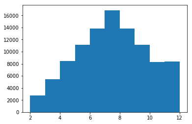

```python
def roll_two_dice():
  return random.randint(1,6) + random.randint(1,6)

rolls=[]
for i in range(100000):
    roll= roll_two_dice()
    rolls.append(roll)
plt.hist(rolls)
```

#### 3. Mean is 7 and variance is 35/6.

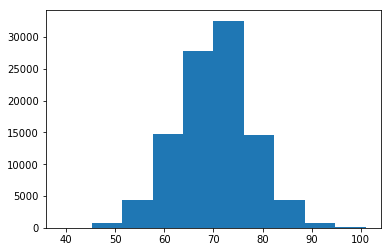

```python
rolls=[]
for i in range(100000):
    roll = 0
    for j in range(10):
        roll += roll_two_dice()
    rolls.append(roll)
plt.hist(rolls)
```